# Análisis descriptivo de variables Actividad: Segmentación de clientes

Alejandro Bedoya

Abril, 2021

```r
library(ggplot2)
library(olsrr)
library(corrplot)
```

# 1. Lectura de la base de datos

```r
#Se carga la base de datos
datos_originales <- read.csv("./datos/base_trabajo_segmentacion.csv",
                             sep = ";")
```

# 2. Limpieza de datos

```r
#Se elimina el guión del nit
datos_originales$nit <- gsub("-","", datos_originales$nit)
```

# Variables correspondientes:

Transacciones mensuales promedio en los diversos canales

- en_tx_canal1
- en_tx_canal2
- en_tx_canal3
- en_tx_canal4
- en_tx_canal5
- en_tx_canal6
- en_tx_canal7
- en_tx_canal8
- en_tx_canal9
- en_tx_canal10
- en_tx_otros

En general son variables numéricas.

## Correlación entre variables

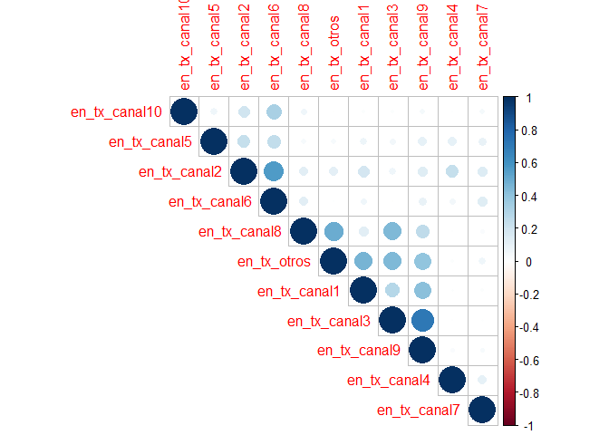

```r
M <- cor(datos_originales[,13:23])
corrplot(M, type="upper", order="hclust")
```

## Histogramas

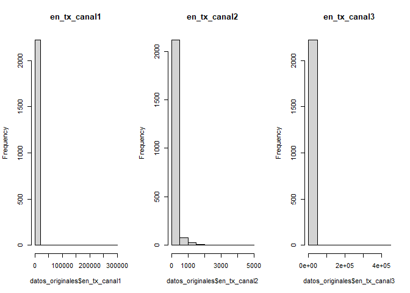

```r
par(mfrow=c(1,3))
hist(datos_originales$en_tx_canal1, main="en_tx_canal1")
hist(datos_originales$en_tx_canal2, main="en_tx_canal2")
hist(datos_originales$en_tx_canal3, main="en_tx_canal3")
```

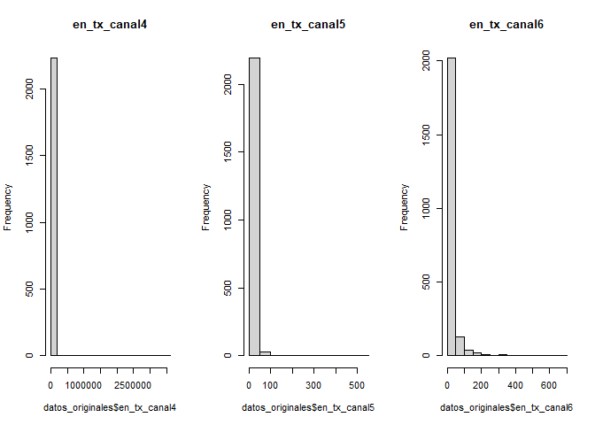

```r
par(mfrow=c(1,3))
hist(datos_originales$en_tx_canal4, main="en_tx_canal4")
hist(datos_originales$en_tx_canal5, main="en_tx_canal5")
hist(datos_originales$en_tx_canal6, main="en_tx_canal6")
```

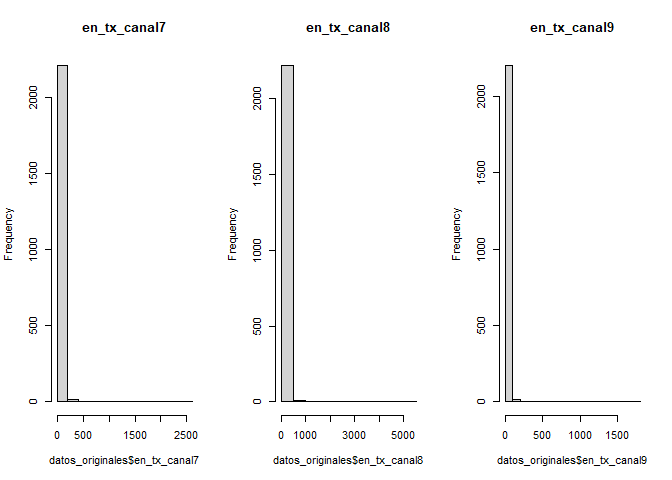

```r
par(mfrow=c(1,3))
hist(datos_originales$en_tx_canal7, main="en_tx_canal7")
hist(datos_originales$en_tx_canal8, main="en_tx_canal8")
hist(datos_originales$en_tx_canal9, main="en_tx_canal9")
```

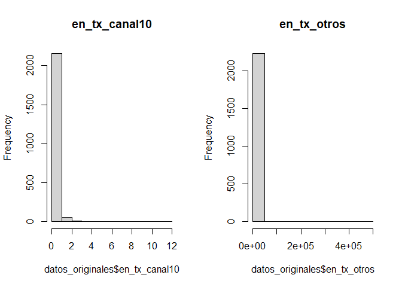

```r
par(mfrow=c(1,2))
hist(datos_originales$en_tx_canal10, main="en_tx_canal10")
hist(datos_originales$en_tx_otros, main = "en_tx_otros")
```

# Análisis individual

## en_tx_canal1

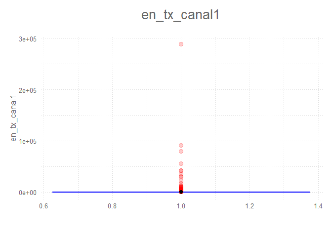

```r
P1 <- ggplot(datos_originales, aes(x=1, y=en_tx_canal1))+
  geom_boxplot(color='blue',fill='blue',alpha=0.2,notch = F,notchwidth = 0.8,
               outlier.colour = 'red',outlier.fill = 'red',outlier.size = 3)+
  labs(title = 'en_tx_canal1',subtitle = ' ',caption = ' ',
       x = ' ', y='en_tx_canal1',color=NULL)+
  theme_elegante()+
  stat_summary(fun=mean,geom='point',shape=21,size=2,color='black',fill='black')
P1
```

Potenciales outliers en_tx_canal1

```r
out_canal1 <- boxplot.stats(datos_originales$en_tx_canal1)$out
out_indices_canal1 <- which(datos_originales$en_tx_canal1 %in% c(out_canal1))

length(out_indices_canal1)
```

```
## [1] 271
```

```r
summary(datos_originales$en_tx_canal1)
```

```
##      Min.   1st Qu.    Median      Mean   3rd Qu.      Max.
##      0.00      4.67     48.08    622.49    235.92 289252.33
```

```r
summary(datos_originales$en_tx_canal1[-out_indices_canal1])
```

```
##    Min. 1st Qu.  Median    Mean 3rd Qu.    Max.
##   0.000   3.333  29.333  94.801 138.104 582.667
```

**Graficos sin outliers para canal1**

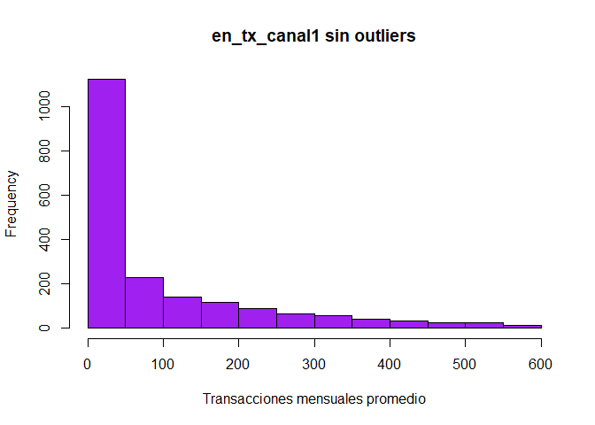

```r
hist(datos_originales$en_tx_canal1[-out_indices_canal1],
     main = "en_tx_canal1 sin outliers",
     col = "purple",
    xlab = "Transacciones mensuales promedio")
```

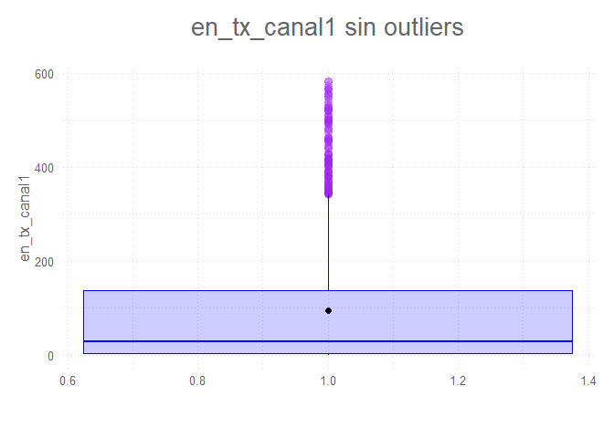

```r
P1 <- ggplot(datos_originales[-out_indices_canal1,], aes(x=1, y=en_tx_canal1))+
  geom_boxplot(color='blue',fill='blue',alpha=0.2,notch = F,notchwidth = 0.8,
               outlier.colour = 'purple',outlier.fill = 'red',outlier.size = 3)+
  labs(title = 'en_tx_canal1 sin outliers',subtitle = ' ',caption = ' ',
       x = ' ', y='en_tx_canal1',color=NULL)+
  theme_elegante()+
  stat_summary(fun=mean,geom='point',shape=21,size=2,color='black',fill='black')
P1
```

# en_tx_canal2

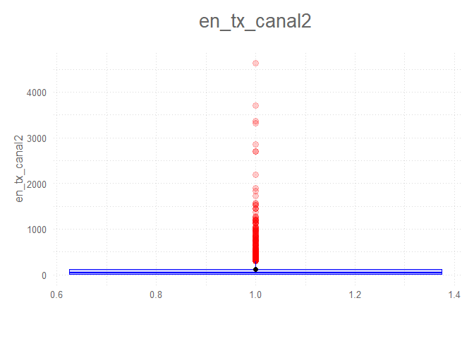

```r
P1 <- ggplot(datos_originales, aes(x=1, y=en_tx_canal2))+
  geom_boxplot(color='blue',fill='blue',alpha=0.2,notch = F,notchwidth = 0.8,
               outlier.colour = 'red',outlier.fill = 'red',outlier.size = 3)+
  labs(title = 'en_tx_canal2',subtitle = ' ',caption = ' ',
       x = ' ', y='en_tx_canal2',color=NULL)+
  theme_elegante()+
  stat_summary(fun=mean,geom='point',shape=21,size=2,color='black',fill='black')
P1
```

Potenciales outliers en_tx_canal2

```r
out_canal2 <- boxplot.stats(datos_originales$en_tx_canal2)$out
out_indices_canal2 <- which(datos_originales$en_tx_canal2 %in% c(out_canal2))

length(out_indices_canal2)
```

```
## [1] 206
```

```r
summary(datos_originales$en_tx_canal2)
```

```
##     Min.  1st Qu.   Median     Mean  3rd Qu.     Max.
##    0.000    7.583   38.250  122.008  122.833 4638.833
```

```r
summary(datos_originales$en_tx_canal2[-out_indices_canal2])
```

```
##    Min. 1st Qu.  Median    Mean 3rd Qu.    Max.
##   0.000   6.275  28.917  59.031  89.625 295.583
```

**Graficos sin outliers para canal2**

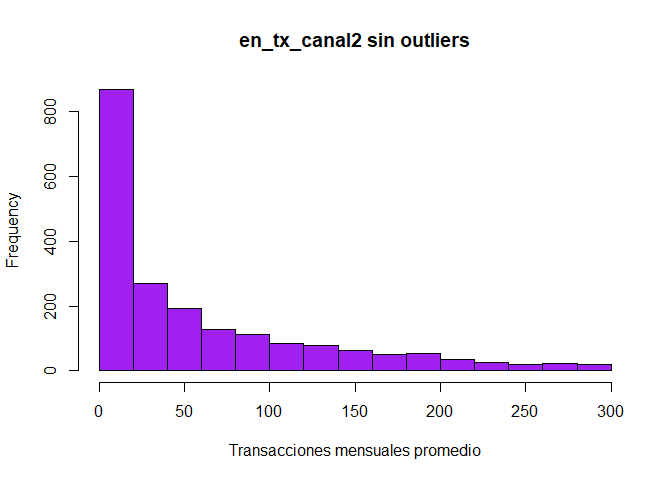

```r
hist(datos_originales$en_tx_canal2[-out_indices_canal2], main = "en_tx_canal2 sin outliers", col = "purple", xlab = "Transacciones mensuales promedio")
```

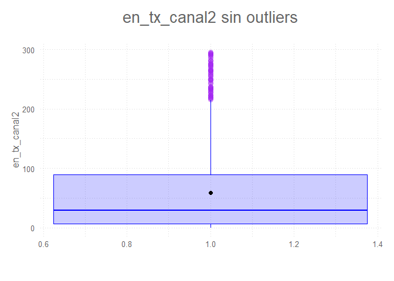

```r
P1 <- ggplot(datos_originales[-out_indices_canal2,], aes(x=1, y=en_tx_canal2))+
  geom_boxplot(color='blue',fill='blue',alpha=0.2,notch = F,notchwidth = 0.8,
               outlier.colour = 'purple',outlier.fill = 'red',outlier.size = 3)+
  labs(title = 'en_tx_canal2 sin outliers',subtitle = ' ',caption = ' ',
       x = ' ', y='en_tx_canal2',color=NULL)+
  theme_elegante()+
  stat_summary(fun=mean,geom='point',shape=21,size=2,color='black',fill='black')
P1
```

# en_tx_canal3

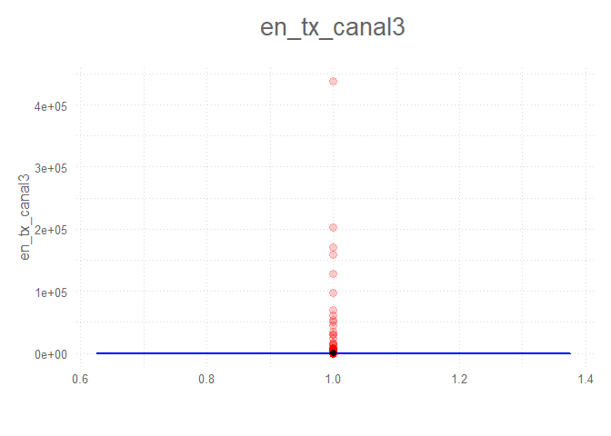

```r
P1 <- ggplot(datos_originales, aes(x=1, y=en_tx_canal3))+
  geom_boxplot(color='blue',fill='blue',alpha=0.2,notch = F,notchwidth = 0.8,
               outlier.colour = 'red',outlier.fill = 'red',outlier.size = 3)+
  labs(title = 'en_tx_canal3',subtitle = ' ',caption = ' ',
       x = ' ', y='en_tx_canal3',color=NULL)+
  theme_elegante()+
  stat_summary(fun=mean,geom='point',shape=21,size=2,color='black',fill='black')
P1
```

Potenciales outliers en_tx_canal3

```r
out_canal3 <- boxplot.stats(datos_originales$en_tx_canal3)$out
out_indices_canal3 <- which(datos_originales$en_tx_canal3 %in% c(out_canal3))

length(out_indices_canal3)
```

```
## [1] 417
```

```r
summary(datos_originales$en_tx_canal3)
```

```
##     Min.  1st Qu.   Median     Mean  3rd Qu.     Max.
##      0.0      0.0      1.9    863.6      8.8 438619.6
```

```r
summary(datos_originales$en_tx_canal3[-out_indices_canal3])
```

```
##    Min. 1st Qu.  Median    Mean 3rd Qu.    Max.
##   0.000   0.000   1.000   2.552   3.000  22.000
```

**Graficos sin outliers para canal3**

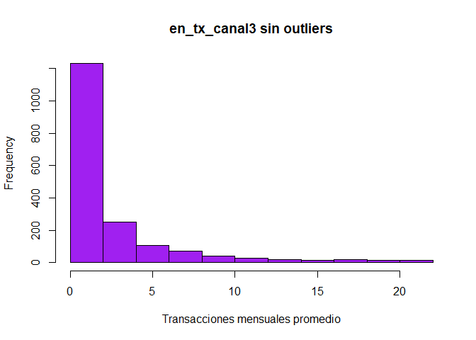

```r
hist(datos_originales$en_tx_canal3[-out_indices_canal3], main = "en_tx_canal3 sin outliers", col = "purple", xlab = "Transacciones mensuales promedio")
```

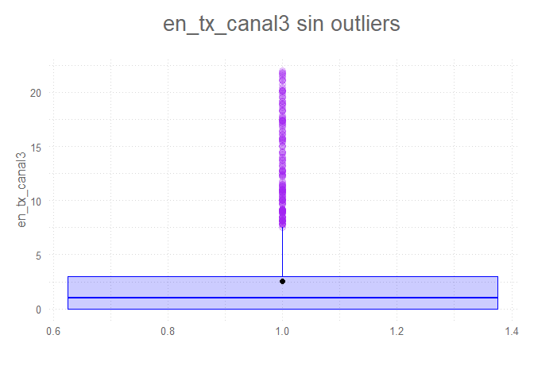

```r
P1 <- ggplot(datos_originales[-out_indices_canal3,], aes(x=1, y=en_tx_canal3))+
  geom_boxplot(color='blue',fill='blue',alpha=0.2,notch = F,notchwidth = 0.8,
               outlier.colour = 'purple',outlier.fill = 'red',outlier.size = 3)+
  labs(title = 'en_tx_canal3 sin outliers',subtitle = ' ',caption = ' ',
       x = ' ', y='en_tx_canal3',color=NULL)+
  theme_elegante()+
  stat_summary(fun=mean,geom='point',shape=21,size=2,color='black',fill='black')
P1
```

# en_tx_canal4

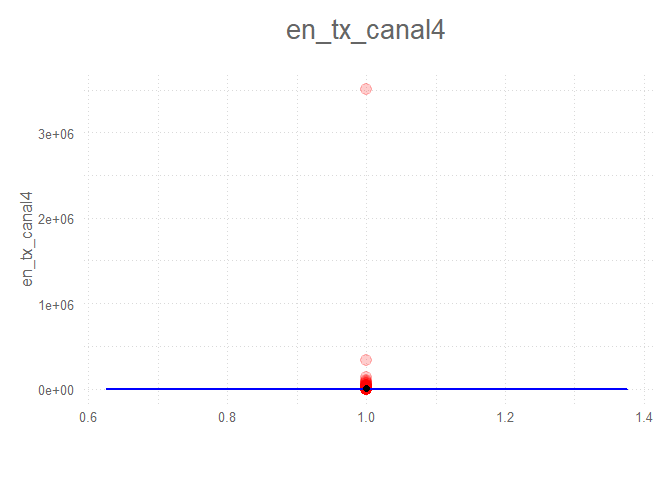

```r
P1 <- ggplot(datos_originales, aes(x=1, y=en_tx_canal4))+
  geom_boxplot(color='blue',fill='blue',alpha=0.2,notch = F,notchwidth = 0.8,
               outlier.colour = 'red',outlier.fill = 'red',outlier.size = 4)+
  labs(title = 'en_tx_canal4',subtitle = ' ',caption = ' ',
       x = ' ', y='en_tx_canal4',color=NULL)+
  theme_elegante()+
  stat_summary(fun=mean,geom='point',shape=21,size=2,color='black',fill='black')
P1
```

Potenciales outliers en_tx_canal4

```r
out_canal4 <- boxplot.stats(datos_originales$en_tx_canal4)$out
out_indices_canal4 <- which(datos_originales$en_tx_canal4 %in% c(out_canal4))

length(out_indices_canal4)
```

```
## [1] 513
```

```r
summary(datos_originales$en_tx_canal4)
```

```
##    Min. 1st Qu.  Median    Mean 3rd Qu.    Max.
##       0       0       0    2624       6 3510700
```

```r
summary(datos_originales$en_tx_canal4[-out_indices_canal4])
```

```
##    Min. 1st Qu.  Median    Mean 3rd Qu.    Max.
##  0.0000  0.0000  0.0000  0.3824  0.0000 14.5000
```

**Graficos sin outliers para canal4**

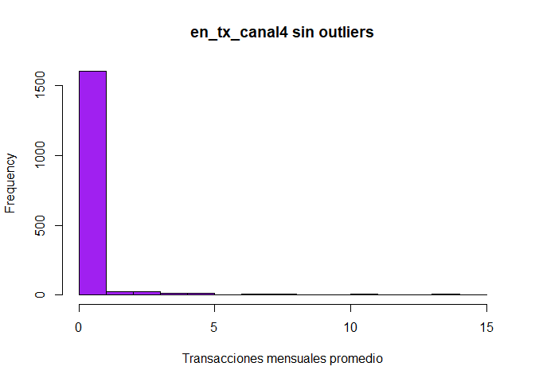

```r
hist(datos_originales$en_tx_canal4[-out_indices_canal4], main = "en_tx_canal4 sin outliers", col = "purple", xlab = "Transacciones mensuales promedio")
```

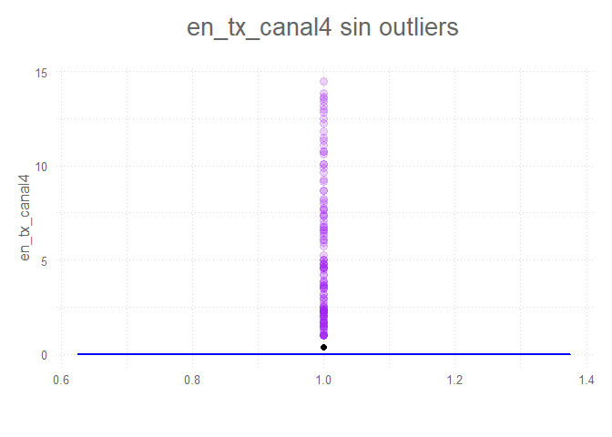

```r
P1 <- ggplot(datos_originales[-out_indices_canal4,], aes(x=1, y=en_tx_canal4))+
  geom_boxplot(color='blue',fill='blue',alpha=0.2,notch = F,notchwidth = 0.8,
               outlier.colour = 'purple',outlier.fill = 'red',outlier.size = 3)+
  labs(title = 'en_tx_canal4 sin outliers',subtitle = ' ',caption = ' ',
       x = ' ', y='en_tx_canal4',color=NULL)+
  theme_elegante()+
  stat_summary(fun=mean,geom='point',shape=21,size=2,color='black',fill='black')
P1
```

# en_tx_canal5

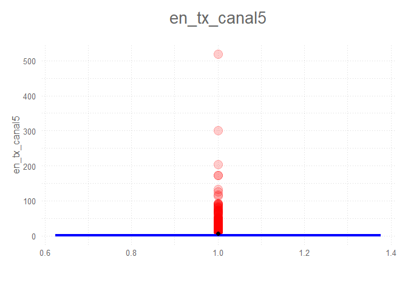

```r
P1 <- ggplot(datos_originales, aes(x=1, y=en_tx_canal5))+
  geom_boxplot(color='blue',fill='blue',alpha=0.2,notch = F,notchwidth = 0.8,
               outlier.colour = 'red',outlier.fill = 'red',outlier.size = 5)+
  labs(title = 'en_tx_canal5',subtitle = ' ',caption = ' ',
       x = ' ', y='en_tx_canal5',color=NULL)+
  theme_elegante()+
  stat_summary(fun=mean,geom='point',shape=21,size=2,color='black',fill='black')
P1
```

Potenciales outliers en_tx_canal5

```r
out_canal5 <- boxplot.stats(datos_originales$en_tx_canal5)$out
out_indices_canal5 <- which(datos_originales$en_tx_canal5 %in% c(out_canal5))


length(out_indices_canal5)
```

```
## [1] 283
```

```r
summary(datos_originales$en_tx_canal5)
```

```
##    Min. 1st Qu.  Median    Mean 3rd Qu.    Max.
##   0.000   0.000   1.000   5.697   4.364 519.167
```

```r
summary(datos_originales$en_tx_canal5[-out_indices_canal5])
```

```
##    Min. 1st Qu.  Median    Mean 3rd Qu.    Max.
##   0.000   0.000   0.000   1.657   2.394  10.833
```

**Graficos sin outliers para canal5**

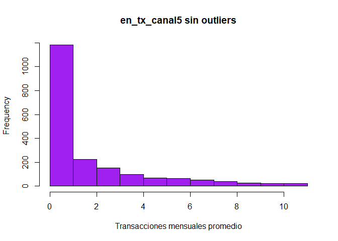

```r
hist(datos_originales$en_tx_canal5[-out_indices_canal5], main = "en_tx_canal5 sin outliers", col = "purple", xlab = "Transacciones mensuales promedio")
```

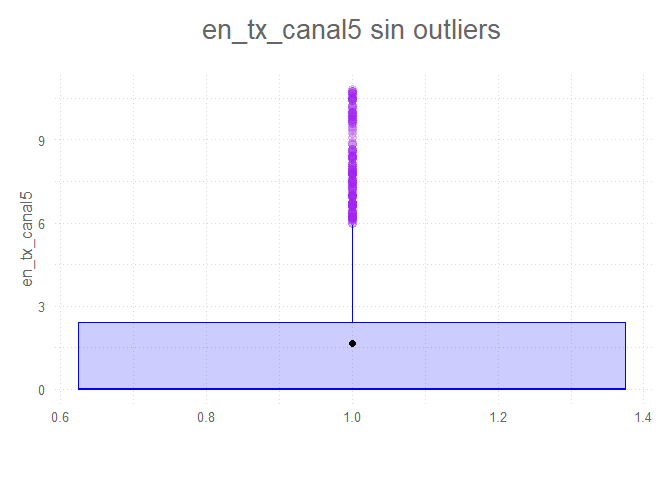

```r
P1 <- ggplot(datos_originales[-out_indices_canal5,], aes(x=1, y=en_tx_canal5))+
  geom_boxplot(color='blue',fill='blue',alpha=0.2,notch = F,notchwidth = 0.8,
               outlier.colour = 'purple',outlier.fill = 'red',outlier.size = 3)+
  labs(title = 'en_tx_canal5 sin outliers',subtitle = ' ',caption = ' ',
       x = ' ', y='en_tx_canal5',color=NULL)+
  theme_elegante()+
  stat_summary(fun=mean,geom='point',shape=21,size=2,color='black',fill='black')
P1
```

# en_tx_canal6

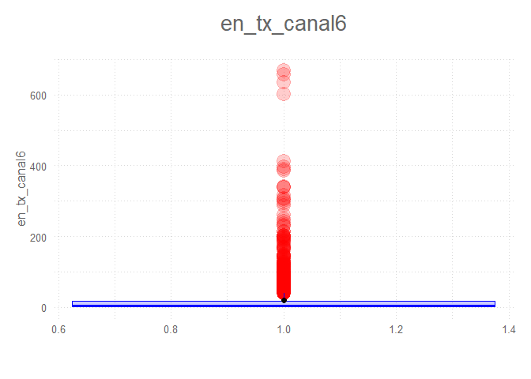

```r
P1 <- ggplot(datos_originales, aes(x=1, y=en_tx_canal6))+
  geom_boxplot(color='blue',fill='blue',alpha=0.2,notch = F,notchwidth = 0.8,
               outlier.colour = 'red',outlier.fill = 'red',outlier.size = 6)+
  labs(title = 'en_tx_canal6',subtitle = ' ',caption = ' ',
       x = ' ', y='en_tx_canal6',color=NULL)+
  theme_elegante()+
  stat_summary(fun=mean,geom='point',shape=21,size=2,color='black',fill='black')
P1
```

Potenciales outliers en_tx_canal6

```r
out_canal6 <- boxplot.stats(datos_originales$en_tx_canal6)$out
out_indices_canal6 <- which(datos_originales$en_tx_canal6 %in% c(out_canal6))

length(out_indices_canal6)
```

```
## [1] 279
```

```r
summary(datos_originales$en_tx_canal6)
```

```
##    Min. 1st Qu.  Median    Mean 3rd Qu.    Max.
##   0.000   1.083   3.889  18.892  16.000 669.667
```

```r
summary(datos_originales$en_tx_canal6[-out_indices_canal6])
```

```
##    Min. 1st Qu.  Median    Mean 3rd Qu.    Max.
##   0.000   1.000   3.000   6.700   8.902  38.333
```

**Graficos sin outliers para canal6**

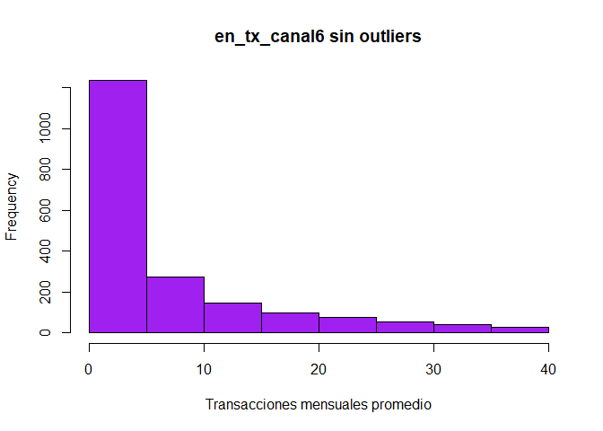

```r
hist(datos_originales$en_tx_canal6[-out_indices_canal6], main = "en_tx_canal6 sin outliers", col = "purple", xlab = "Transacciones mensuales promedio")
```

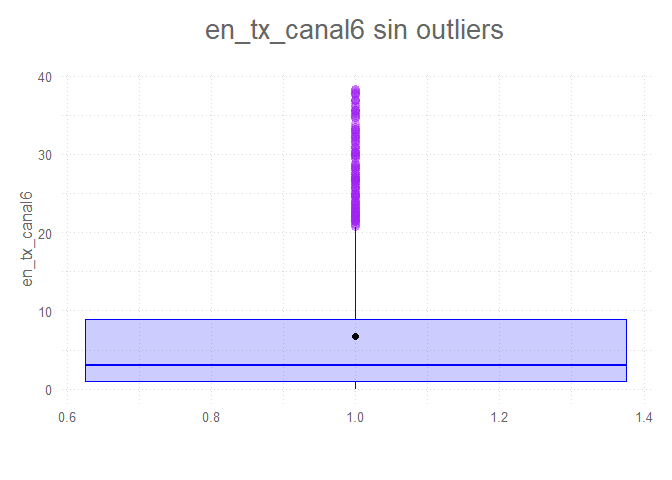

```r
P1 <- ggplot(datos_originales[-out_indices_canal6,], aes(x=1, y=en_tx_canal6))+
  geom_boxplot(color='blue',fill='blue',alpha=0.2,notch = F,notchwidth = 0.8,
               outlier.colour = 'purple',outlier.fill = 'red',outlier.size = 3)+
  labs(title = 'en_tx_canal6 sin outliers',subtitle = ' ',caption = ' ',
       x = ' ', y='en_tx_canal6',color=NULL)+
  theme_elegante()+
  stat_summary(fun=mean,geom='point',shape=21,size=2,color='black',fill='black')
P1
```

# en_tx_canal7

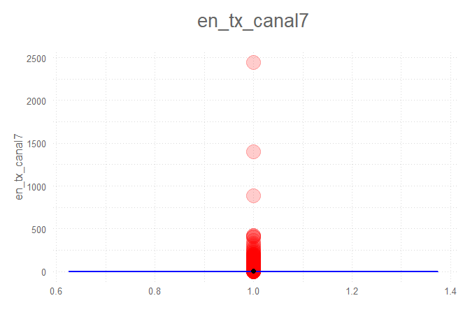

```r
P1 <- ggplot(datos_originales, aes(x=1, y=en_tx_canal7))+
  geom_boxplot(color='blue',fill='blue',alpha=0.2,notch = F,notchwidth = 0.8,
               outlier.colour = 'red',outlier.fill = 'red',outlier.size = 7)+
  labs(title = 'en_tx_canal7',subtitle = ' ',caption = ' ',
       x = ' ', y='en_tx_canal7',color=NULL)+
  theme_elegante()+
  stat_summary(fun=mean,geom='point',shape=21,size=2,color='black',fill='black')
P1
```

Potenciales outliers en_tx_canal7

```r
out_canal7 <- boxplot.stats(datos_originales$en_tx_canal7)$out
out_indices_canal7 <- which(datos_originales$en_tx_canal7 %in% c(out_canal7))


length(out_indices_canal7)
```

```
## [1] 205
```

```r
summary(datos_originales$en_tx_canal7)
```

```
##     Min.  1st Qu.   Median     Mean  3rd Qu.     Max.
##    0.000    0.000    0.000    7.822    0.000 2446.500
```

```r
summary(datos_originales$en_tx_canal7[-out_indices_canal7])
```

```
##    Min. 1st Qu.  Median    Mean 3rd Qu.    Max.
##       0       0       0       0       0       0
```

**Graficos sin outliers para canal7**

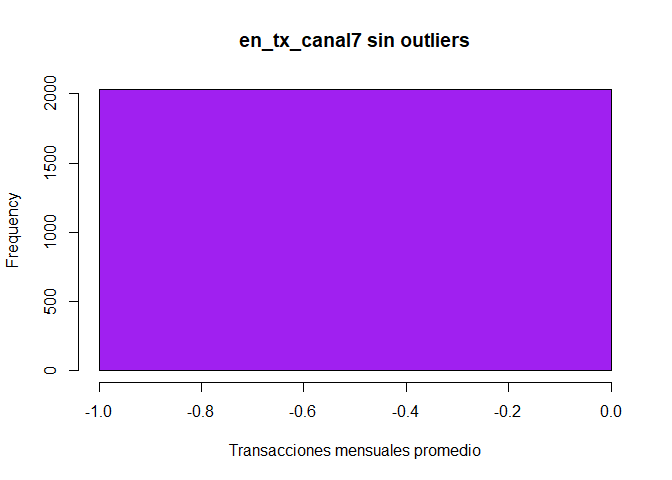

```r
hist(datos_originales$en_tx_canal7[-out_indices_canal7], main = "en_tx_canal7 sin outliers", col = "purple", xlab = "Transacciones mensuales promedio")
```

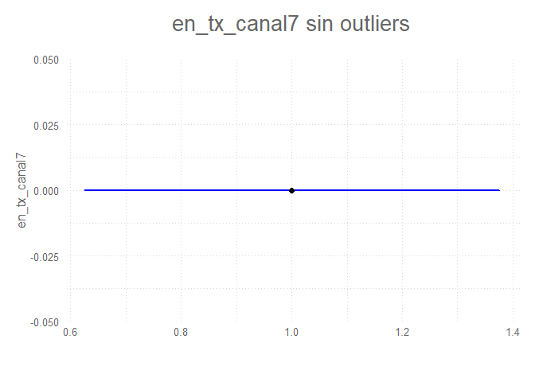

```r
P1 <- ggplot(datos_originales[-out_indices_canal7,], aes(x=1, y=en_tx_canal7))+
  geom_boxplot(color='blue',fill='blue',alpha=0.2,notch = F,notchwidth = 0.8,
               outlier.colour = 'purple',outlier.fill = 'red',outlier.size = 3)+
  labs(title = 'en_tx_canal7 sin outliers',subtitle = ' ',caption = ' ',
       x = ' ', y='en_tx_canal7',color=NULL)+
  theme_elegante()+
  stat_summary(fun=mean,geom='point',shape=21,size=2,color='black',fill='black')
P1
```

# en_tx_canal8

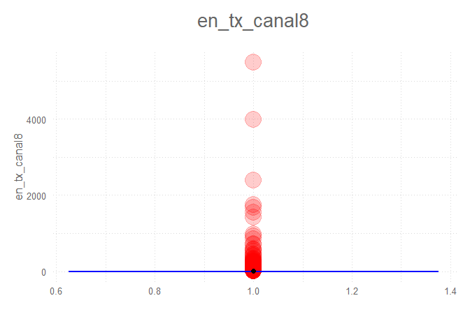

```r
P1 <- ggplot(datos_originales, aes(x=1, y=en_tx_canal8))+
  geom_boxplot(color='blue',fill='blue',alpha=0.2,notch = F,notchwidth = 0.8,
               outlier.colour = 'red',outlier.fill = 'red',outlier.size = 8)+
  labs(title = 'en_tx_canal8',subtitle = ' ',caption = ' ',
       x = ' ', y='en_tx_canal8',color=NULL)+
  theme_elegante()+
  stat_summary(fun=mean,geom='point',shape=21,size=2,color='black',fill='black')
P1
```

Potenciales outliers en_tx_canal8

```r
out_canal8 <- boxplot.stats(datos_originales$en_tx_canal8)$out
out_indices_canal8 <- which(datos_originales$en_tx_canal8 %in% c(out_canal8))


length(out_indices_canal8)
```

```
## [1] 337
```

```r
summary(datos_originales$en_tx_canal8)
```

```
##     Min.  1st Qu.   Median     Mean  3rd Qu.     Max.
##    0.000    0.000    1.333   20.843    3.833 5492.667
```

```r
summary(datos_originales$en_tx_canal8[-out_indices_canal8])
```

```
##    Min. 1st Qu.  Median    Mean 3rd Qu.    Max.
##   0.000   0.000   1.000   1.560   2.143   9.500
```

**Graficos sin outliers para canal8**

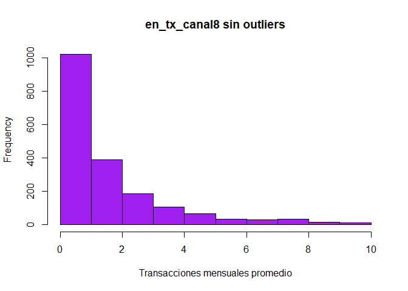

```r
hist(datos_originales$en_tx_canal8[-out_indices_canal8], main = "en_tx_canal8 sin outliers", col = "purple", xlab = "Transacciones mensuales promedio")
```

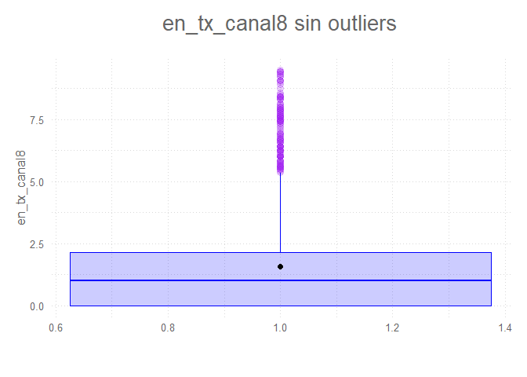

```r
P1 <- ggplot(datos_originales[-out_indices_canal8,], aes(x=1, y=en_tx_canal8))+
  geom_boxplot(color='blue',fill='blue',alpha=0.2,notch = F,notchwidth = 0.8,
               outlier.colour = 'purple',outlier.fill = 'red',outlier.size = 3)+
  labs(title = 'en_tx_canal8 sin outliers',subtitle = ' ',caption = ' ',
       x = ' ', y='en_tx_canal8',color=NULL)+
  theme_elegante()+
  stat_summary(fun=mean,geom='point',shape=21,size=2,color='black',fill='black')
P1
```

# en_tx_canal9

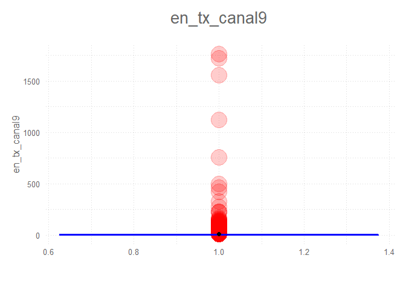

```r
P1 <- ggplot(datos_originales, aes(x=1, y=en_tx_canal9))+
  geom_boxplot(color='blue',fill='blue',alpha=0.2,notch = F,notchwidth = 0.8,
               outlier.colour = 'red',outlier.fill = 'red',outlier.size = 9)+
  labs(title = 'en_tx_canal9',subtitle = ' ',caption = ' ',
       x = ' ', y='en_tx_canal9',color=NULL)+
  theme_elegante()+
  stat_summary(fun=mean,geom='point',shape=21,size=2,color='black',fill='black')
P1
```

Potenciales outliers en_tx_canal9

```r
out_canal9 <- boxplot.stats(datos_originales$en_tx_canal9)$out
out_indices_canal9 <- which(datos_originales$en_tx_canal9 %in% c(out_canal9))

length(out_indices_canal9)
```

```
## [1] 297
```

```r
summary(datos_originales$en_tx_canal9[-out_indices_canal9])
```

```
##    Min. 1st Qu.  Median    Mean 3rd Qu.    Max.
##   0.000   0.000   1.000   1.836   2.548  10.400
```

**Graficos sin outliers para canal9**

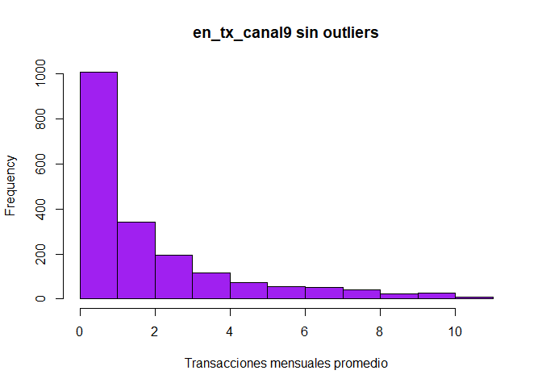

```r
hist(datos_originales$en_tx_canal9[-out_indices_canal9], main = "en_tx_canal9 sin outliers", col = "purple", xlab = "Transacciones mensuales promedio")
```

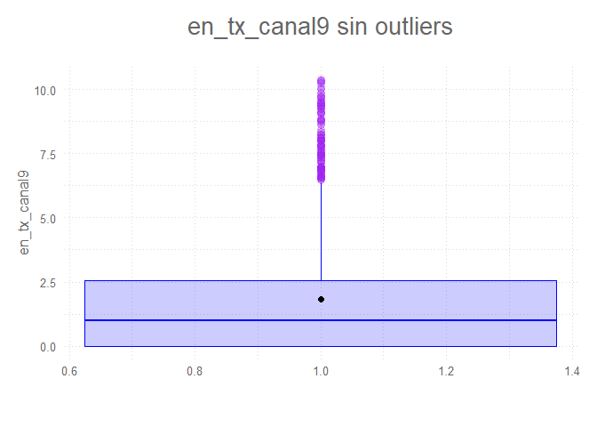

```r
P1 <- ggplot(datos_originales[-out_indices_canal9,], aes(x=1, y=en_tx_canal9))+
  geom_boxplot(color='blue',fill='blue',alpha=0.2,notch = F,notchwidth = 0.8,
               outlier.colour = 'purple',outlier.fill = 'red',outlier.size = 3)+
  labs(title = 'en_tx_canal9 sin outliers',subtitle = ' ',caption = ' ',
       x = ' ', y='en_tx_canal9',color=NULL)+
  theme_elegante()+
  stat_summary(fun=mean,geom='point',shape=21,size=2,color='black',fill='black')
P1
```